### HW3

#### A.Identify two surveys

I use World Values Survey: Wave 4 (1999 - 2004) and Wave 6 (2010 - 2014), to finish this work. I would like to invesitigate how people in different countries describe themselves as belonging to different social classes. Such social classes include: Working class, Middle Class (Upper or Lower), Upper class and Lower Class.

#### B.Describe the graghs that you intend to make

I use stacked barplots to show the percentages of each social class. Besides, I make some comparisions between the Wave 4 and Wave 6 plots figure out if any countries change a lot with regard to this question, during this ten-year period.

#### C. Write down the target shape of the data

{country:“China, United States,Japan…”, year:“1999,2000,…,2014”, wave:“4,6”, Social Class =“working class,…upper class”}

#### D.E & F. Write a script, make graphs and write expressive function calls

In this part, firstly, I write a script that reads, transforms and prepares data for my graphs; then I rewrite all of the original script into function calls and make graphs.

```r
# install.packages('foreign') install.packages('reshape2')
# install.packages('ggplot2')
library(foreign)
library(reshape2)
library(ggplot2)
```

##### Function 1:Set Work Directory and Load Data

###### Input : “WV4_Data_spss_v_2014-04-28.sav”

###### data: WV4 Data

```r
f1 <- function(filename, workingdirectory) {
    setwd(workingdirectory)
    data = read.spss(filename)
    return(data)
}
data = f1("WV4_Data_spss_v_2014-04-28.sav", "~/Downloads")
```

```
## re-encoding from UTF-8
```

##### Function 2: Create proportional tables from data by country

###### First, I convert the the country variable into a string; then I create unweighted proportional tables from data

```r
f2 <- function(data) {
    data$v2 <- as.character(data$v2)
    tblB <- as.data.frame(prop.table(table(data$v2, data$v235), 1) * 100)
    tbl3 <- tblB[tblB$Var2 %in% c("Lower class", "Lower middle class", "Upper class",
        "Upper middle class", "Working class"), ]
    tbl3$Var2 <- factor(tbl3$Var2, levels = c("Lower class", "Lower middle class",
        "Upper class", "Upper middle class", "Working class"))
    return(tbl3)
}
tbl3 = f2(data)
```

##### Function 3: Reshape the data and relevel the levels to match the daulft colors better

```r
f3 <- function() {
    orderDat3 <- dcast(tbl3, Var1 ~ Var2, value.var = "Freq")
    tblPlot3 <- melt(orderDat3, id.vars = "Var1", measure.vars = c("Lower class",
        "Lower middle class", "Upper class", "Upper middle class", "Working class"))
    tblPlot3$variable <- factor(tblPlot3$variable, levels = c("Lower class",
        "Lower middle class", "Upper class", "Upper middle class", "Working class"))
    return(tblPlot3)
}
tblPlot3 = f3()
```

#### Then I Make a Graph for WV4

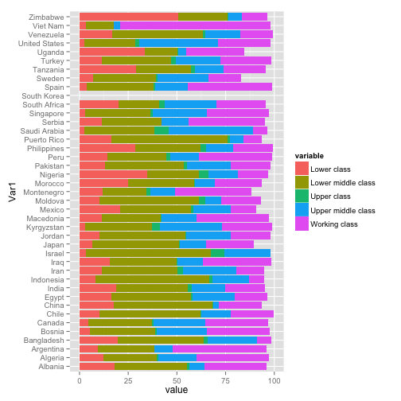

```r
ggplot(tblPlot3, aes(x = Var1, y = value, fill = variable)) + geom_bar(stat = "identity") +
    coord_flip()
```

#### Repeat procedures for Data for Wave 6

##### Function 4: Load Data for Wave 6

```r
setwd("~/Downloads")
f4 <- function(filename) {
    data2 = read.spss(filename)
    return(data2)
}
data2 = f4("WV6_Data_spss_v_2014_06_04.sav")
```

```
## re-encoding from UTF-8
```

##### Function 5: Create proportional tables from data by country

###### First, I convert the the country variable into a string; then I create unweighted proportional tables from data

```r
f5 <- function(data2) {
    data2$V2 <- as.character(data2$V2)
    tblC <- as.data.frame(prop.table(table(data2$V2, data2$V238), 1) * 100)
    tbl4 <- tblC[tblC$Var2 %in% c("Lower class", "Lower middle class", "Upper class",
        "Upper middle class", "Working class"), ]
    tbl4$Var2 <- factor(tbl4$Var2, levels = c("Lower class", "Lower middle class",
        "Upper class", "Upper middle class", "Working class"))
    return(tbl4)
}
tbl4 = f5(data2)
```

##### Function 6: Reshape the data and relevel the levels to match the daulft colors better

```r
f6 <- function() {
    orderDat4 <- dcast(tbl4, Var1 ~ Var2, value.var = "Freq")
    tblPlot4 <- melt(orderDat4, id.vars = "Var1", measure.vars = c("Lower class",
        "Lower middle class", "Upper class", "Upper middle class", "Working class"))
    tblPlot4$variable <- factor(tblPlot4$variable, levels = c("Lower class",
        "Lower middle class", "Upper class", "Upper middle class", "Working class"))
    return(tblPlot4)
}
tblPlot4 = f6()
```

#### Then I make a graph for WV6

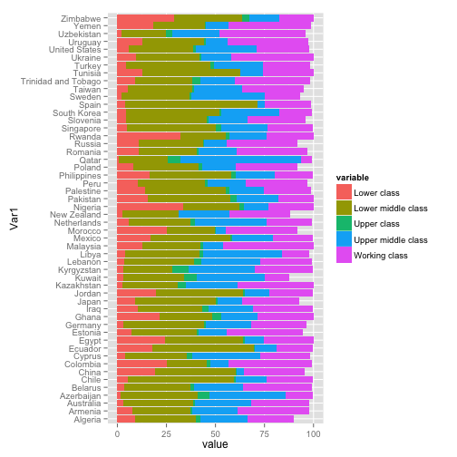

```r
ggplot(tblPlot4, aes(x = Var1, y = value, fill = variable)) + geom_bar(stat = "identity") +
    coord_flip()
```

From both plots above, we can see that for China, more people regard themselves as belonging to the working class instead of lower middle class ten years later. Many more fun facts are waiting to be noticed.